# KNN Regression, KNN Classification, LDA, QDA, Naive Bayes

Hajin Jang

10/8/2025

## Concept

#### If the Bayes decision boundary is linear, do we expect LDA or QDA to perform better on the training set? On the test set?

On the training data, QDA is generally expected to perform better because its greater flexibility allows it to model more complex boundaries. Even if the true decision boundary is linear, QDA can still capture subtle patterns specific to the training set, which typically lowers training error. On the test data, LDA is expected to perform better. Since it assumes a linear boundary, LDA better matches the underlying data structure. Its lower flexibility helps prevent overfitting and supports stronger generalization, whereas QDA’s greater flexibility can lead to overfitting, increased variance, and weaker test performance.

#### If the Bayes decision boundary is non-linear, do we expect LDA or QDA to perform better on the training set? On the test set?

QDA is expected to outperform on both the training and test sets. Its greater flexibility enables it to capture non-linear relationships more accurately. Because the true decision boundary is non-linear, QDA provides a closer fit, making it better suited for both training and test data.

#### In general, as the sample size n increases, do we expect the test prediction accuracy of QDA relative to LDA to improve, decline, or be unchanged? Why?

To improve. Compared to LDA, QDA is more flexible but requires estimating more parameters, which can cause overfitting and weaker generalization when the sample size is small. As the sample size grows, QDA can estimate these parameters more reliably, which enhances test accuracy and reduces overfitting. LDA, on the other hand, relies on a simpler linear boundary, so its performance is steadier but gains less from larger sample sizes.

#### Even if the Bayes decision boundary for a given problem is linear, we will probably achieve a superior test error rate using QDA rather than LDA because QDA is flexible enough to model a linear decision boundary. Justify your answer.

False. While QDA can represent a linear decision boundary, it is more complex and involves estimating a larger number of parameters. When the true boundary is linear, LDA is better suited because it assumes a shared covariance structure across classes, making the model simpler and less prone to overfitting. In contrast, QDA’s extra flexibility can lead to overfitting the training data.

## Part 1: KNN Regression

```r
library(ISLR2)
library(FNN)
library(caret)
library(tidyverse)
head(Carseats)
```

```
##   Sales CompPrice Income Advertising Population Price ShelveLoc Age Education
## 1  9.50       138     73          11        276   120       Bad  42        17
## 2 11.22       111     48          16        260    83      Good  65        10
## 3 10.06       113     35          10        269    80    Medium  59        12
## 4  7.40       117    100           4        466    97    Medium  55        14
## 5  4.15       141     64           3        340   128       Bad  38        13
## 6 10.81       124    113          13        501    72       Bad  78        16
##   Urban  US
## 1   Yes Yes
## 2   Yes Yes
## 3   Yes Yes
## 4   Yes Yes
## 5   Yes  No
## 6    No Yes
```

#### Training and testing sets (70/30)

```r
set.seed(0911)
train <- sample(1:nrow(Carseats), size=ceiling(nrow(Carseats)*.7))
```

```r
str(train)
```

```
##  int [1:280] 302 195 334 141 191 17 178 311 376 233 ...
```

```r
length(train)
```

```
## [1] 280
```

```r
train[1:10]
```

```
##  [1] 302 195 334 141 191  17 178 311 376 233
```

```r
length(train)/nrow(Carseats)
```

```
## [1] 0.7
```

#### Preprocessing

##### One-hot coding

```r
Carseats.xmat <- model.matrix(Sales~., data=Carseats[,-c(2:5, 7:9)])
str(Carseats.xmat)
```

```
##  num [1:400, 1:4] 1 1 1 1 1 1 1 1 1 1 ...
##  - attr(*, "dimnames")=List of 2
##   ..$ : chr [1:400] "1" "2" "3" "4" ...
##   ..$ : chr [1:4] "(Intercept)" "Price" "UrbanYes" "USYes"
##  - attr(*, "assign")= int [1:4] 0 1 2 3
##  - attr(*, "contrasts")=List of 2
##   ..$ Urban: chr "contr.treatment"
##   ..$ US   : chr "contr.treatment"
```

```r
Carseats.xmat[1:10,]
```

```
##    (Intercept) Price UrbanYes USYes
## 1            1   120        1     1
## 2            1    83        1     1
## 3            1    80        1     1
## 4            1    97        1     1
## 5            1   128        1     0
## 6            1    72        0     1
## 7            1   108        1     0
## 8            1   120        1     1
## 9            1   124        0     0
## 10           1   124        0     1
```

```r
Carseats.xmat <- Carseats.xmat[,-1]
```

##### Standardization

```r
Carseats.xmat[1:10,]
```

```
##    Price UrbanYes USYes
## 1    120        1     1
## 2     83        1     1
## 3     80        1     1
## 4     97        1     1
## 5    128        1     0
## 6     72        0     1
## 7    108        1     0
## 8    120        1     1
## 9    124        0     0
## 10   124        0     1
```

```r
Carseats.XConTr <- Carseats.xmat[train, 1, drop = FALSE]
Carseats.XCatTr <- Carseats.xmat[train,2:3]
```

```r
preProcVals<- preProcess(Carseats.XConTr, method=c("center", "scale"))
str(preProcVals)
```

```
## List of 21
##  $ dim              : int [1:2] 280 1
##  $ bc               : NULL
##  $ yj               : NULL
##  $ et               : NULL
##  $ invHyperbolicSine: NULL
##  $ mean             : Named num 116
##   ..- attr(*, "names")= chr "Price"
##  $ std              : Named num 23.9
##   ..- attr(*, "names")= chr "Price"
##  $ ranges           : NULL
##  $ rotation         : NULL
##  $ method           :List of 3
##   ..$ center: chr "Price"
##   ..$ scale : chr "Price"
##   ..$ ignore: chr(0)
##  $ thresh           : num 0.95
##  $ pcaComp          : NULL
##  $ numComp          : NULL
##  $ ica              : NULL
##  $ wildcards        :List of 2
##   ..$ PCA: chr(0)
##   ..$ ICA: chr(0)
##  $ k                : num 5
##  $ knnSummary       :function (x, ...)
##  $ bagImp           : NULL
##  $ median           : NULL
##  $ data             : NULL
##  $ rangeBounds      : num [1:2] 0 1
##  - attr(*, "class")= chr "preProcess"
```

```r
Carseats.XConTrZ <- predict(preProcVals, Carseats.XConTr)
Carseats.XTrZ <- cbind(Carseats.XConTrZ, Carseats.XCatTr)
```

```r
dim(Carseats.XTrZ)
```

```
## [1] 280   3
```

```r
Carseats.XTrZ[1:5,]
```

```
##          Price UrbanYes USYes
## 302 -1.2188787        1     1
## 195  0.4997073        1     1
## 334  1.2961252        1     1
## 141  0.5416241        1     1
## 191 -0.6320444        0     1
```

```r
summary(Carseats.XTrZ)
```

```
##      Price             UrbanYes          USYes
##  Min.   :-3.85963   Min.   :0.0000   Min.   :0.0000
##  1st Qu.:-0.68444   1st Qu.:0.0000   1st Qu.:0.0000
##  Median : 0.03862   Median :1.0000   Median :1.0000
##  Mean   : 0.00000   Mean   :0.7286   Mean   :0.6536
##  3rd Qu.: 0.58354   3rd Qu.:1.0000   3rd Qu.:1.0000
##  Max.   : 3.14046   Max.   :1.0000   Max.   :1.0000
```

##### Validation set

```r
Carseats.XConVal <- Carseats.xmat[-train,1,drop = FALSE]
Carseats.XCatVal <- Carseats.xmat[-train,2:3]
Carseats.XConValZ <- predict(preProcVals, Carseats.XConVal)
Carseats.XValZ <- cbind(Carseats.XConValZ, Carseats.XCatVal)
dim(Carseats.XValZ)
```

```
## [1] 120   3
```

```r
Carseats.XValZ[1:5,]
```

```
##         Price UrbanYes USYes
## 3  -1.5122958        1     1
## 7  -0.3386273        1     0
## 18  0.6254575        1     1
## 20  0.2062902        1     1
## 21  0.6254575        1     1
```

```r
summary(Carseats.XValZ)
```

```
##      Price             UrbanYes        USYes
##  Min.   :-2.64405   Min.   :0.00   Min.   :0.000
##  1st Qu.:-0.63204   1st Qu.:0.00   1st Qu.:0.000
##  Median : 0.14342   Median :1.00   Median :1.000
##  Mean   :-0.03962   Mean   :0.65   Mean   :0.625
##  3rd Qu.: 0.63594   3rd Qu.:1.00   3rd Qu.:1.000
##  Max.   : 2.30213   Max.   :1.00   Max.   :1.000
```

#### Fitting KNN regression

```r
set.seed(123)

mKnnReg <- function(trainDat, validDat, trainOut, validOut, k){
 mseKNN <- rep(NA, times=length(k))
 for (i in 1:length(k)) {
 out <- FNN::knn.reg(train=trainDat, test=validDat, y=trainOut, k=k[i])
 mseKNN[i] <- mean((out$pred-validOut)^2)
 }
 return(mseKNN)
}


Kvec <- 1:30

mseKNN <- mKnnReg(trainDat=Carseats.XTrZ, validDat=Carseats.XValZ, trainOut=Carseats$Sales[train], validOut=Carseats$Sales[-train], k=Kvec)

mseKNN
```

```
##  [1] 11.179416  7.717521  7.232824  6.722110  6.636834  6.648537  6.631348
##  [8]  6.590729  6.600527  6.601781  6.593522  6.531031  6.614528  6.499638
## [15]  6.442778  6.480031  6.340036  6.236756  6.221807  6.331557  6.411140
## [22]  6.337144  6.325778  6.357180  6.216684  6.148008  6.159944  6.174554
## [29]  6.193686  6.155719
```

#### Plotting 1/K (x-axis) versus MSE (y-axis)

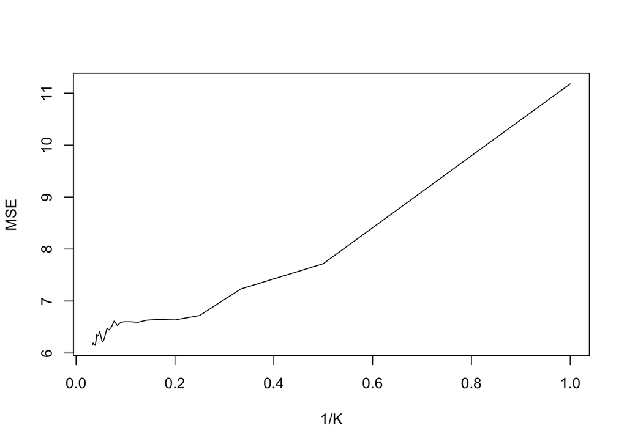

```r
plot(1/Kvec, mseKNN, type="l", xlab="1/K", ylab="MSE")
```

```r
kopt <- which.min(mseKNN)
kopt
```

```
## [1] 26
```

```r
bestMSE <- mseKNN[kopt]
bestMSE
```

```
## [1] 6.148008
```

```r
bestK <- Kvec[kopt]
bestK
```

```
## [1] 26
```

```r
knnpred <- FNN::knn.reg(train=Carseats.XTrZ, test=Carseats.XValZ, y=Carseats$Sales[train], k=kopt)
```

**Comment:** The optimal K value is 26, as it yields the lowest validation MSE among all tested values, indicating the best predictive performance of the model.

#### Interpretation

##### Price

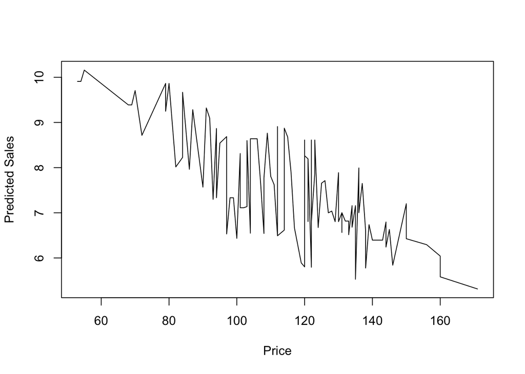

```r
plotdat <- data.frame(Price=Carseats$Price[-train], Urban=Carseats$Urban[-train], US=Carseats$US[-train], Sales=knnpred$pred)

plotdat <- plotdat[order(plotdat$Price),]
plot(x=plotdat$Price, y=plotdat$Sales, type="l", xlab="Price", ylab="Predicted Sales")
```

As the price increases, the predicted sales go down. Once the price exceeds 100, the variability in predicted sales increases, showing noticeable spikes and drops. This implies that other factors besides price may be influencing sales predictions.

##### Urban

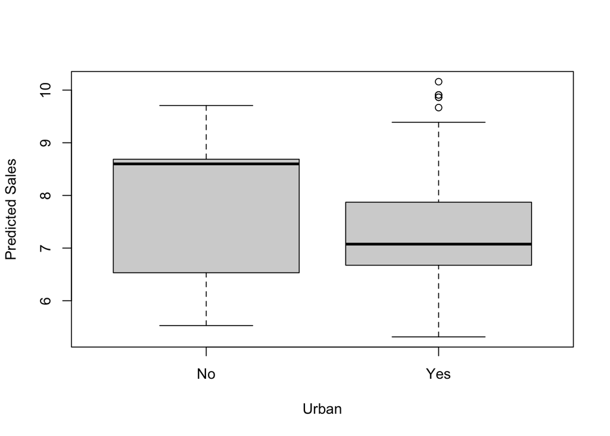

```r
plotdat <- plotdat[order(plotdat$Urban),]
boxplot(plotdat$Sales~plotdat$Urban, ylab="Predicted Sales", xlab="Urban")
```

The non-urban group has a higher median predicted sales than the urban group and a wider interquartile range, indicating greater variability in sales predictions for non-urban areas. In contrast, the urban group shows a narrower IQR, suggesting less variability, but includes several high-value outliers. Overall, predicted sales in non-urban areas are generally higher and more dispersed, while urban areas tend to have lower, more tightly clustered sales with a few extreme values.

##### US

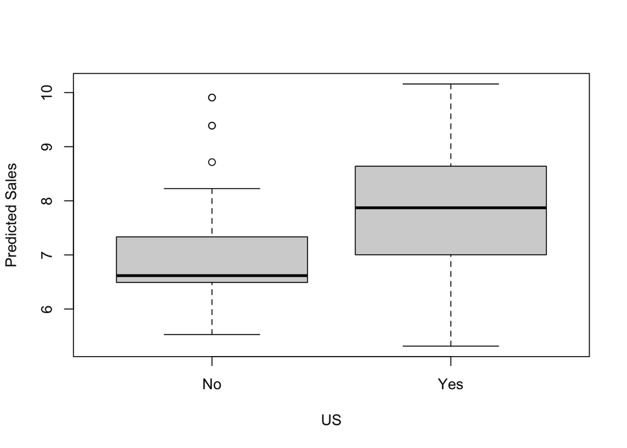

```r
plotdat <- plotdat[order(plotdat$US),]
boxplot(plotdat$Sales~plotdat$US, ylab="Predicted Sales", xlab="US")
```

The US group has a higher median predicted sales compared to the non-US group and has a broader interquartile range, indicating greater variability within its predictions. The non-US group, while generally showing lower predicted sales, has several high-value outliers. This suggests that although most predictions for the non-US group are lower, a few cases stand out with unusually high sales. Overall, the US group shows a wider spread in predicted sales, indicating more variation across its data points.

## Part 2

#### mpg01 variable

```r
library(dplyr)
library(tidyverse)
library(MASS)
library(ISLR2)
library(caret)
library(e1071)
library(class)
data("Auto")
str(Auto)
```

```
## 'data.frame':    392 obs. of  9 variables:
##  $ mpg         : num  18 15 18 16 17 15 14 14 14 15 ...
##  $ cylinders   : int  8 8 8 8 8 8 8 8 8 8 ...
##  $ displacement: num  307 350 318 304 302 429 454 440 455 390 ...
##  $ horsepower  : int  130 165 150 150 140 198 220 215 225 190 ...
##  $ weight      : int  3504 3693 3436 3433 3449 4341 4354 4312 4425 3850 ...
##  $ acceleration: num  12 11.5 11 12 10.5 10 9 8.5 10 8.5 ...
##  $ year        : int  70 70 70 70 70 70 70 70 70 70 ...
##  $ origin      : int  1 1 1 1 1 1 1 1 1 1 ...
##  $ name        : Factor w/ 304 levels "amc ambassador brougham",..: 49 36 231 14 161 141 54 223 241 2 ...
##  - attr(*, "na.action")= 'omit' Named int [1:5] 33 127 331 337 355
##   ..- attr(*, "names")= chr [1:5] "33" "127" "331" "337" ...
```

```r
# median of mpg
mpg_median <- median(Auto$mpg)

# create mpg01
Auto <- Auto %>%
  mutate(mpg01 = ifelse(mpg > mpg_median, 1, 0),
         mpg01 = as.factor(mpg01),
         origin = as.factor(origin))

#Auto <- cbind(Auto, data.frame("mpg01" = ifelse(Auto$mpg > mpg_median, 1, 0)))

str(Auto)
```

```
## 'data.frame':    392 obs. of  10 variables:
##  $ mpg         : num  18 15 18 16 17 15 14 14 14 15 ...
##  $ cylinders   : int  8 8 8 8 8 8 8 8 8 8 ...
##  $ displacement: num  307 350 318 304 302 429 454 440 455 390 ...
##  $ horsepower  : int  130 165 150 150 140 198 220 215 225 190 ...
##  $ weight      : int  3504 3693 3436 3433 3449 4341 4354 4312 4425 3850 ...
##  $ acceleration: num  12 11.5 11 12 10.5 10 9 8.5 10 8.5 ...
##  $ year        : int  70 70 70 70 70 70 70 70 70 70 ...
##  $ origin      : Factor w/ 3 levels "1","2","3": 1 1 1 1 1 1 1 1 1 1 ...
##  $ name        : Factor w/ 304 levels "amc ambassador brougham",..: 49 36 231 14 161 141 54 223 241 2 ...
##  $ mpg01       : Factor w/ 2 levels "0","1": 1 1 1 1 1 1 1 1 1 1 ...
##  - attr(*, "na.action")= 'omit' Named int [1:5] 33 127 331 337 355
##   ..- attr(*, "names")= chr [1:5] "33" "127" "331" "337" ...
```

```r
table(Auto$mpg01)
```

```
##
##   0   1
## 196 196
```

#### EDA

##### 1) Cylinders

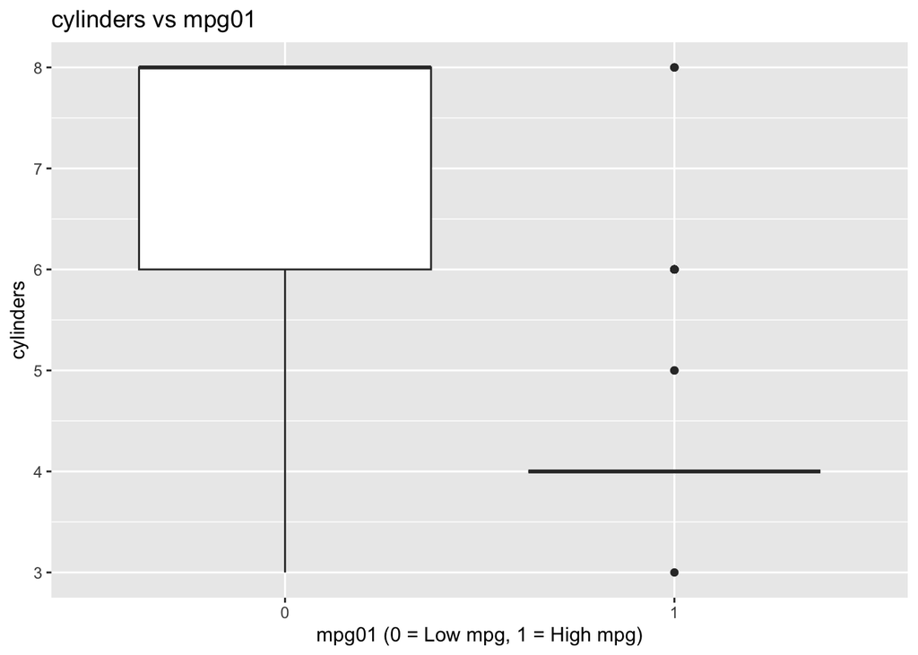

```r
library(ggplot2)
ggplot(Auto, aes(x = mpg01, y = cylinders)) +
  geom_boxplot() +
  labs(title = "cylinders vs mpg01", x = "mpg01 (0 = Low mpg, 1 = High mpg)", y = "cylinders")
```

Cars with low mpg (mpg01 = 0) tend to have a significantly higher median number of cylinders than those with high mpg (mpg01 = 1). The interquartile range is also wider for the low-mpg group, indicating more variability in cylinder counts among less fuel-efficient cars. The boxplot shows a negative relationship between cylinder count and gas mileage. Vehicles with more cylinders generally have lower mpg. This clear distinction between the two groups suggests that the number of cylinders could be a useful predictor for mpg01.

##### 2) Displacement

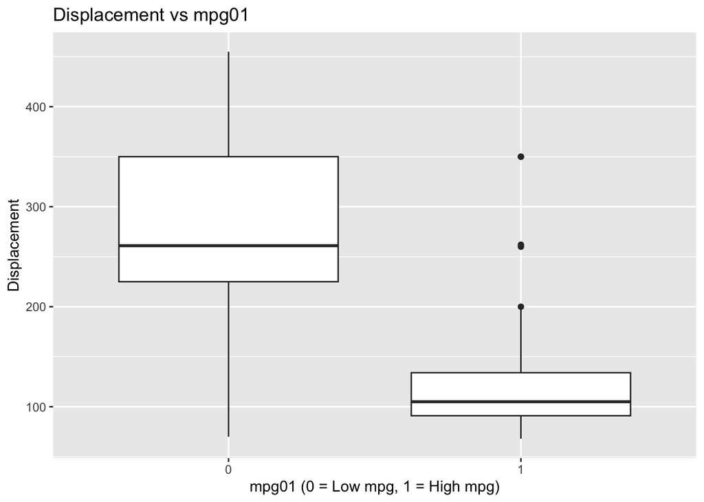

```r
ggplot(Auto, aes(x = mpg01, y = displacement)) +
  geom_boxplot() +
  labs(title = "Displacement vs mpg01", x = "mpg01 (0 = Low mpg, 1 = High mpg)", y = "Displacement")
```

Cars with low mpg (mpg01 = 0) show a much higher median engine displacement than those with high mpg (mpg01 = 1). They also have a wider interquartile range, indicating more variation in displacement among less fuel-efficient vehicles. The boxplot suggests a negative correlation between engine displacement and mpg, with larger displacements linked to lower fuel efficiency. Given the clear visual separation between the two groups, displacement appears to be a useful predictor of mpg01.

##### 3) Horsepower

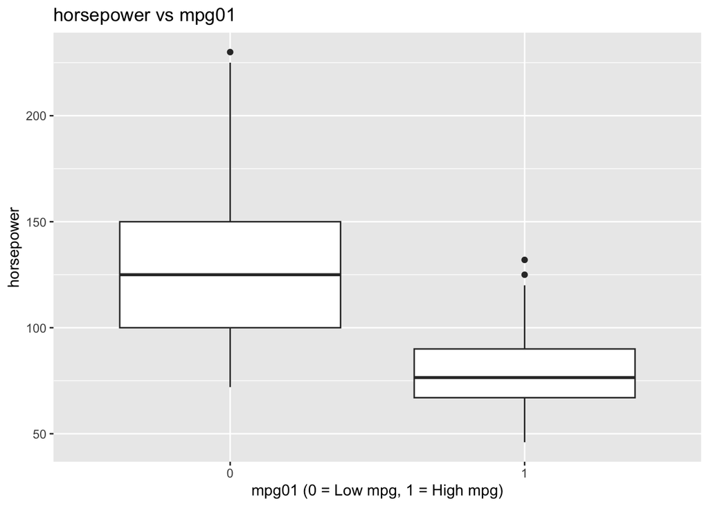

```r
ggplot(Auto, aes(x = mpg01, y = horsepower)) +
  geom_boxplot() +
  labs(title = "horsepower vs mpg01", x = "mpg01 (0 = Low mpg, 1 = High mpg)", y = "horsepower")
```

Cars with low mpg (mpg01 = 0) tend to have a much higher median horsepower than those with high mpg (mpg01 = 1). The interquartile range is wider for the low-mpg group, indicating greater variability in horsepower among less fuel-efficient cars. The boxplot indicates a negative relationship between horsepower and mpg, with higher horsepower linked to lower fuel efficiency. The clear visual distinction between the two groups suggests that horsepower could be a useful predictor of mpg01.

##### 4) Weight

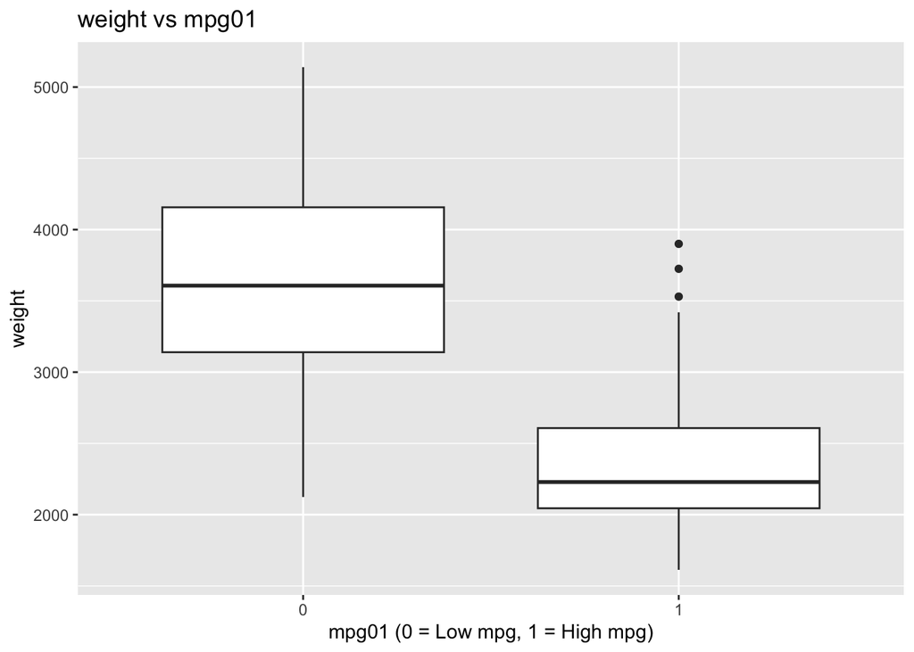

```r
ggplot(Auto, aes(x = mpg01, y = weight)) +
  geom_boxplot() +
  labs(title = "weight vs mpg01", x = "mpg01 (0 = Low mpg, 1 = High mpg)", y = "weight")
```

Cars with low mpg (mpg01 = 0) have a significantly higher median vehicle weight than those with high mpg (mpg01 = 1). They also show a wider interquartile range, suggesting more variation in weight among less fuel-efficient vehicles. The boxplot shows a negative correlation between vehicle weight and mpg, indicating that heavier cars tend to have lower fuel efficiency. Given the clear visual difference between the groups, vehicle weight appears to be a useful predictor of mpg01.

##### 5) Acceleration

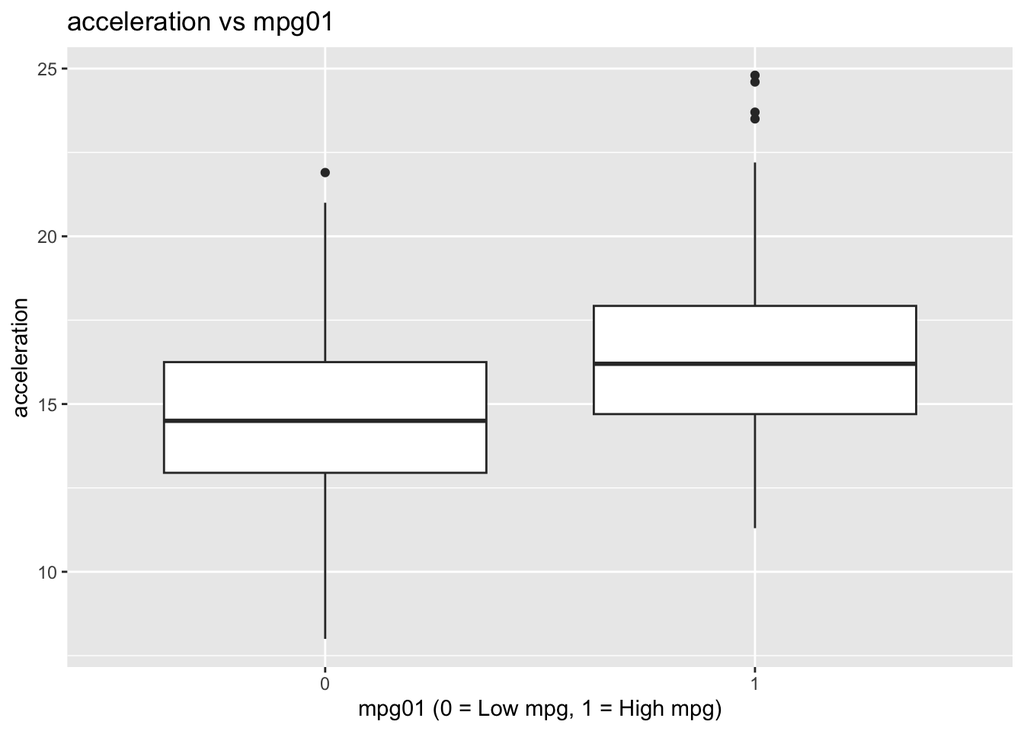

```r
ggplot(Auto, aes(x = mpg01, y = acceleration)) +
  geom_boxplot() +
  labs(title = "acceleration vs mpg01", x = "mpg01 (0 = Low mpg, 1 = High mpg)", y = "acceleration")
```

Cars with low mpg tend to have lower acceleration times compared to those with high mpg. The boxplot suggests a slight positive relationship between acceleration and fuel efficiency, but the difference between the two groups is not very pronounced. Since the distinction isn’t clear, I would not consider acceleration a strong predictor of mpg01.

##### 6) Year

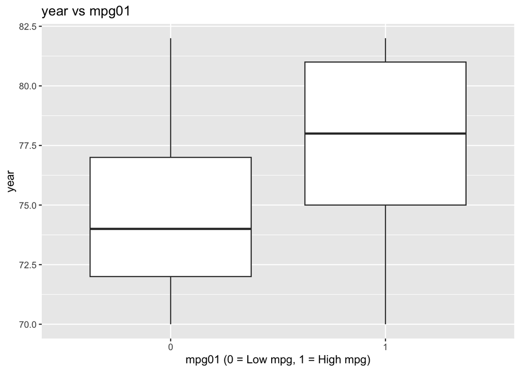

```r
ggplot(Auto, aes(x = mpg01, y = year)) +
  geom_boxplot() +
  labs(title = "year vs mpg01", x = "mpg01 (0 = Low mpg, 1 = High mpg)", y = "year")
```

Cars produced in more recent years generally have higher MPG than those from the early 1970s. However, the correlation doesn’t appear to be strong, as there is noticeable overlap between the two groups. Since the difference isn’t clearly defined, I would not consider the year of production a strong predictor of mpg01.

##### 7) Origin

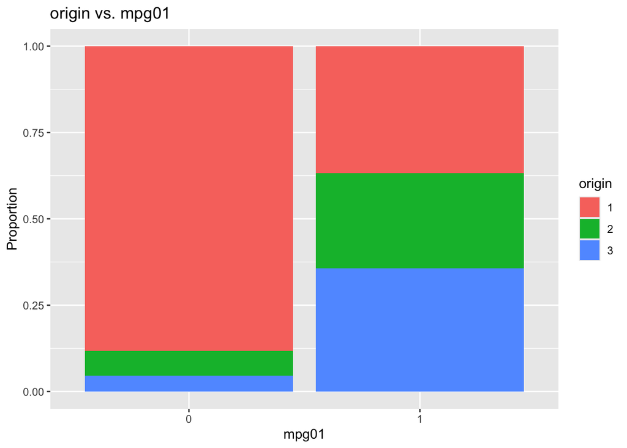

```r
library(ggplot2)
ggplot(Auto, aes(x = mpg01, fill = origin)) +
  geom_bar(position = "fill") +  # Stacked bars with proportions
  labs(title = "origin vs. mpg01",
       x = "mpg01",
       y = "Proportion",
       fill = "origin")
```

**In conclusion:** Based on the plots above, **cylinders, displacement, horsepower, and weight** appear to be the most promising variables for predicting mpg01.

#### Training and testing datasets

```r
set.seed(123)
train <-createDataPartition(Auto$mpg01, p=0.7, list=FALSE)
Auto.tr <- Auto[train, ]
Auto.te <- Auto[-train, ]
nrow(Auto.tr)
```

```
## [1] 276
```

```r
nrow(Auto.te)
```

```
## [1] 116
```

#### LDA

```r
ConfusionMatrix <- function(pred, truth){
  conf_table <- table(pred, truth)
  print(conf_table)
  acc <- sum(diag(conf_table)) / sum(conf_table)
  cat("Overall Accuracy:", round(acc, 4), "\n")
  return(conf_table)
}

set.seed(123)

lda_fit <- lda(mpg01 ~ cylinders + displacement + horsepower + weight,
               data = Auto.tr)
lda_pred <- predict(lda_fit, Auto.te)

lda_conf <- ConfusionMatrix(lda_pred$class, Auto.te$mpg01)
```

```
##     truth
## pred  0  1
##    0 50  3
##    1  8 55
## Overall Accuracy: 0.9052
```

```r
lda_error <- (lda_conf[1,2] + lda_conf[2,1]) / sum(lda_conf)
lda_error
```

```
## [1] 0.09482759
```

#### Logistic regression

```r
set.seed(123)

logit_fit <- glm(mpg01 ~ cylinders + displacement + horsepower + weight,
                 family = binomial(link = "logit"), data = Auto.tr)
logit_prob <- predict(logit_fit, Auto.te, type = "response")
logit_pred <- as.factor(ifelse(logit_prob > 0.5, "Yes", "No"))

logit_conf <- ConfusionMatrix(logit_pred, Auto.te$mpg01)
```

```
##      truth
## pred   0  1
##   No  51  6
##   Yes  7 52
## Overall Accuracy: 0.8879
```

```r
logit_error <- (logit_conf[1,2] + logit_conf[2,1]) / sum(logit_conf)
logit_error
```

```
## [1] 0.112069
```

#### KNN

```r
knn_trainX = Auto.tr %>% dplyr::select(cylinders, displacement, horsepower, weight)
knn_testX = Auto.te%>% dplyr::select(cylinders, displacement, horsepower, weight)

mKnnClass <- function(trainDat, validDat, trainOut, validOut, k){
  confKNN <- list(NA, times=length(k))
  accKNN <- rep(NA, times=length(k))
  for (i in 1:length(k)) {
     out <- knn(train=trainDat, test=validDat, cl=trainOut, k=k[i])
     confKNN[[i]] <- confusionMatrix(out, validOut)
     accKNN[i] <- confKNN[[i]]$overall[1]
 }
 return(list(conf=confKNN, accuracy=accKNN))
}

# set your vector for K
Kvec <- 1:30

confKNN <- mKnnClass(trainDat=knn_trainX, validDat=knn_testX, trainOut=Auto.tr$mpg01, validOut=Auto.te$mpg01, k=Kvec)
confKNN[[2]]
```

```
##  [1] 0.8793103 0.8793103 0.8965517 0.8879310 0.9051724 0.9051724 0.8965517
##  [8] 0.9137931 0.8965517 0.8965517 0.8965517 0.8879310 0.8965517 0.8793103
## [15] 0.8965517 0.8879310 0.8879310 0.8879310 0.8879310 0.8879310 0.8879310
## [22] 0.8793103 0.8879310 0.8879310 0.8879310 0.8879310 0.8879310 0.8793103
## [29] 0.8793103 0.8879310
```

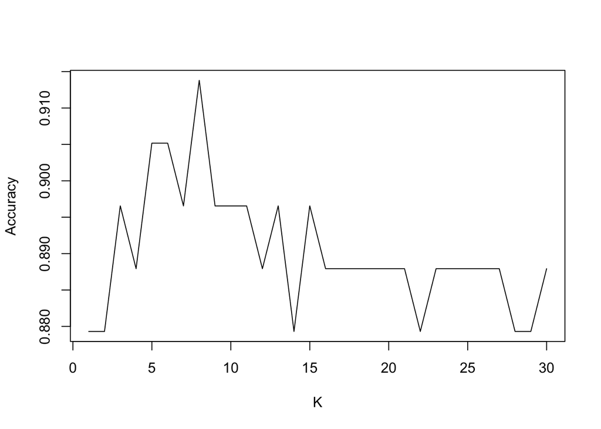

```r
plot(Kvec, confKNN[[2]], type="l", xlab="K", ylab="Accuracy", xlim=c(min(Kvec), max(Kvec)))
```

```r
kopt <- which.max(confKNN[[2]])
kopt
```

```
## [1] 8
```

```r
confKNN_best <- mKnnClass(trainDat=knn_trainX, validDat=knn_testX, trainOut=Auto.tr$mpg01, validOut=Auto.te$mpg01, k=kopt)
KNN_error <- 1-confKNN_best[[2]]
KNN_error
```

```
## [1] 0.0862069
```

#### Scalining and centering

```r
# scale training set
preProcVals<- preProcess(knn_trainX, method=c("center", "scale"))
knn_trainz <- predict(preProcVals, knn_trainX)
str(knn_trainz)
```

```
## 'data.frame':    276 obs. of  4 variables:
##  $ cylinders   : num  1.49 1.49 1.49 1.49 1.49 ...
##  $ displacement: num  1.1 1.07 1.05 2.28 2.52 ...
##  $ horsepower  : num  0.683 1.207 0.945 2.465 3.042 ...
##  $ weight      : num  0.662 0.576 0.596 1.675 1.69 ...
##  - attr(*, "na.action")= 'omit' Named int [1:5] 33 127 331 337 355
##   ..- attr(*, "names")= chr [1:5] "33" "127" "331" "337" ...
```

```r
# scale testing set
knn_testz <- predict(preProcVals, knn_testX)
str(knn_testz)
```

```
## 'data.frame':    116 obs. of  4 variables:
##  $ cylinders   : num  1.495 1.495 1.495 1.495 -0.873 ...
##  $ displacement: num  1.513 1.203 1.9 1.832 -0.781 ...
##  $ horsepower  : num  1.6 1.207 2.255 1.731 -0.235 ...
##  $ weight      : num  0.891 0.58 1.081 0.734 -0.707 ...
##  - attr(*, "na.action")= 'omit' Named int [1:5] 33 127 331 337 355
##   ..- attr(*, "names")= chr [1:5] "33" "127" "331" "337" ...
```

```r
confKNN_z <- mKnnClass(trainDat=knn_trainz, validDat=knn_testz, trainOut=Auto.tr$mpg01, validOut=Auto.te$mpg01, k=Kvec)
confKNN_z
```

[output not shown]

[output cut: 823 more lines]

```
##              Prevalence : 0.5000
##          Detection Rate : 0.4310
##    Detection Prevalence : 0.4655
##       Balanced Accuracy : 0.8966
##
##        'Positive' Class : 0
##
##
##
## $accuracy
##  [1] 0.8879310 0.8534483 0.9137931 0.9396552 0.9051724 0.9137931 0.9310345
##  [8] 0.9224138 0.8965517 0.8965517 0.8965517 0.8965517 0.8965517 0.8965517
## [15] 0.8965517 0.8965517 0.8965517 0.8965517 0.8965517 0.8965517 0.8965517
## [22] 0.8965517 0.8965517 0.8965517 0.8965517 0.8965517 0.8965517 0.8965517
## [29] 0.8965517 0.8965517
```

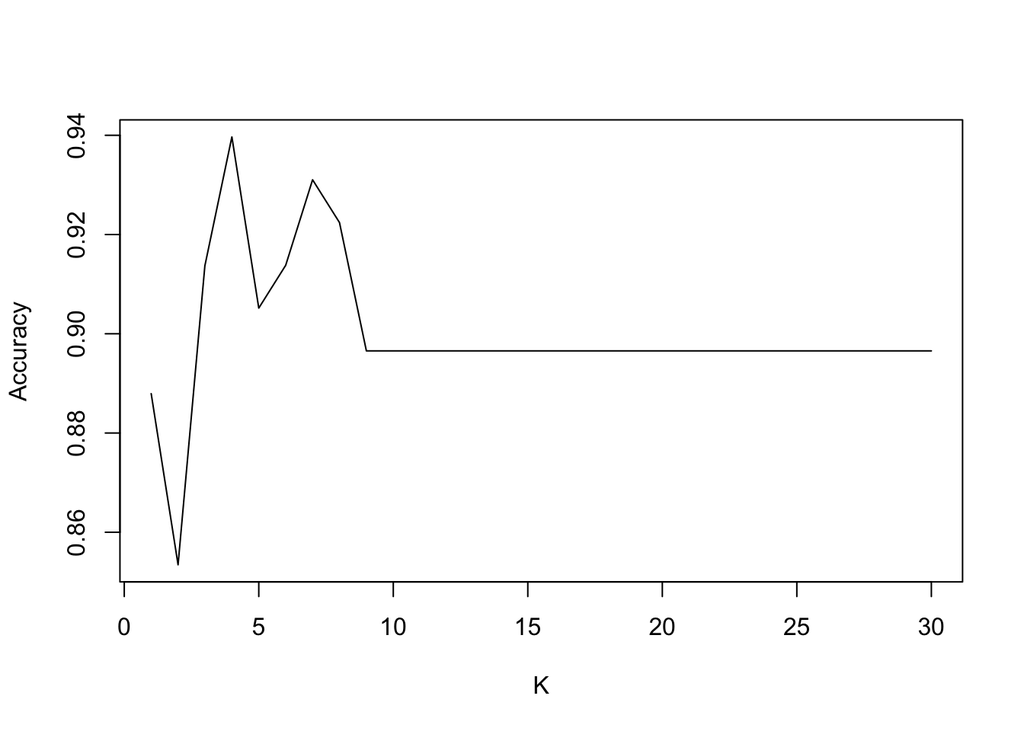

```r
plot(Kvec, confKNN_z[[2]], type="l", xlab="K", ylab="Accuracy", xlim=c(min(Kvec), max(Kvec)))
```

```r
kopt_z <- which.max(confKNN_z[[2]])
kopt_z
```

```
## [1] 4
```

```r
confKNN_best_z <- mKnnClass(trainDat=knn_trainz, validDat=knn_testz, trainOut=Auto.tr$mpg01, validOut=Auto.te$mpg01, k=kopt_z)
knn_error_z <- 1-confKNN_best_z[[2]]
knn_error_z
```

```
## [1] 0.07758621
```

**Explanation:** KNN relies on distance calculations to classify data points, so when features have different units or ranges, those with larger scales may dominate the distance measure, regardless of their true importance. By standardizing continuous variables (mean of 0 and standard deviation of 1), all features are placed on a similar scale. This ensures a more balanced contribution to distance calculations, resulting in better classification accuracy.